# Maintenance Model for Engine

## Description

The dataset consists of 10 000 data points stored as rows with 14 features in columns

1. UID: unique identifier ranging from 1 to 10000
2. product ID: consisting of a letter L, M, or H for low (60% of all products), medium (30%) and high (10%) as product quality variants and a variant-specific serial number"
3. air temperature [K]: generated using a random walk process later normalized to a standard deviation of 2 K around 300 K
4. process temperature [K]: generated using a random walk process normalized to a standard deviation of 1 K, added to the air temperature plus 10 K."
5. rotational speed [rpm]: calculated from a power of 2860 W, overlaid with a normally distributed noise"
6. torque [Nm]: torque values are normally distributed around 40 Nm with a σ = 10 Nm and no negative values.
7. tool wear [min]: The quality variants H/M/L add 5/3/2 minutes of tool wear to the used tool in the process.
8. machine failure' label that indicates, whether the machine has failed in this particular datapoint for any of the following failure modes are true.

If at least one of the above failure modes is true, the process fails and the 'machine failure' label is set to 1. It is therefore not transparent to the machine learning method, which of the failure modes has caused the process to fail

```python
import numpy as np
import pandas as pd
import matplotlib.pyplot as plt
import seaborn as sns
# sns.set(font_scale = 1.2)
from sklearn.metrics import f1_score, roc_auc_score, accuracy_score, precision_score, recall_score
from sklearn.metrics import classification_report, confusion_matrix, roc_curve
import joblib
from imblearn.over_sampling import SMOTE
from imblearn.combine import SMOTETomek
from collections import Counter
from sklearn.model_selection import train_test_split, RandomizedSearchCV
from sklearn.ensemble import RandomForestClassifier
```

```python
def print_results(y_test, y_pred, multi_class = False):

    #f1-score
    if multi_class == True:
        f1 = f1_score(y_test, y_pred, average="macro")
    else:
        f1 = f1_score(y_test, y_pred)
    print("F1 Score: ", f1)
    print(classification_report(y_test, y_pred))

    conf_matrix = confusion_matrix(y_test, y_pred)
    plt.figure(figsize=(12,12))
    plt.subplot(221)
    sns.heatmap(conf_matrix, fmt = "d",annot=True, cmap='Blues')
    b, t = plt.ylim()
    plt.ylim(b + 0.5, t - 0.5)
    plt.title('Confuion Matrix')
    plt.ylabel('True Values')
    plt.xlabel('Predicted Values')

    #roc_auc_score
    if multi_class == False:
        model_roc_auc = roc_auc_score(y_test, y_pred)
        print ("Area under curve : ",model_roc_auc,"\n")
        fpr,tpr,thresholds = roc_curve(y_test, y_pred)
        gmeans = np.sqrt(tpr * (1-fpr))
        ix = np.argmax(gmeans)
        threshold = np.round(thresholds[ix],3)

        plt.subplot(222)
        plt.plot(fpr, tpr, color='darkorange', lw=1, label = "Auc : %.3f" %model_roc_auc)
        plt.plot([0, 1], [0, 1], color='navy', lw=2, linestyle='--')
        plt.scatter(fpr[ix], tpr[ix], marker='o', color='black', label='Best Threshold:' + str(threshold))
        plt.xlim([0.0, 1.0])
        plt.ylim([0.0, 1.05])
        plt.xlabel('False Positive Rate')
        plt.ylabel('True Positive Rate')
        plt.title('Receiver operating characteristic')
        plt.legend(loc="lower right")
    return f1
```

```python
df = pd.read_csv('ai4i2020.csv', delimiter="\t").drop('UDI',axis=1)
df
```

|  | Product ID | Type | Air temperature [K] | Process temperature [K] | Rotational speed [rpm] | Torque [Nm] | Tool wear [min] | Machine failure | TWF | HDF | PWF | OSF | RNF |
| --- | --- | --- | --- | --- | --- | --- | --- | --- | --- | --- | --- | --- | --- |
| 0 | M14860 | M | 298.1 | 308.6 | 1551 | 42.8 | 0 | 0 | 0 | 0 | 0 | 0 | 0 |
| 1 | L47181 | L | 298.2 | 308.7 | 1408 | 46.3 | 3 | 0 | 0 | 0 | 0 | 0 | 0 |
| 2 | L47182 | L | 298.1 | 308.5 | 1498 | 49.4 | 5 | 0 | 0 | 0 | 0 | 0 | 0 |
| 3 | L47183 | L | 298.2 | 308.6 | 1433 | 39.5 | 7 | 0 | 0 | 0 | 0 | 0 | 0 |
| 4 | L47184 | L | 298.2 | 308.7 | 1408 | 40.0 | 9 | 0 | 0 | 0 | 0 | 0 | 0 |
| ... | ... | ... | ... | ... | ... | ... | ... | ... | ... | ... | ... | ... | ... |
| 9995 | M24855 | M | 298.8 | 308.4 | 1604 | 29.5 | 14 | 0 | 0 | 0 | 0 | 0 | 0 |
| 9996 | H39410 | H | 298.9 | 308.4 | 1632 | 31.8 | 17 | 0 | 0 | 0 | 0 | 0 | 0 |
| 9997 | M24857 | M | 299.0 | 308.6 | 1645 | 33.4 | 22 | 0 | 0 | 0 | 0 | 0 | 0 |
| 9998 | H39412 | H | 299.0 | 308.7 | 1408 | 48.5 | 25 | 0 | 0 | 0 | 0 | 0 | 0 |
| 9999 | M24859 | M | 299.0 | 308.7 | 1500 | 40.2 | 30 | 0 | 0 | 0 | 0 | 0 | 0 |

10000 rows × 13 columns

```python
df['Machine failure'].value_counts()
```

```
0    9661
1     339
Name: Machine failure, dtype: int64
```

```python
def col_info(df,spaces,*args):
    cols = df.columns
    print(*list(map(lambda x:str(x).ljust(spaces),("Column","Unique Items", "Unique Values"))),sep='')
    print('-'*(spaces*3))
    for col in cols:
        print(*list(map(lambda x:str(x).ljust(spaces),(col,df[col].nunique(),'-' if df[col].nunique()>3 else df[ col].unique()))),sep='')

col_info(df,25)
```

```
Column                   Unique Items             Unique Values
---------------------------------------------------------------------------
Product ID               10000                    -
Type                     3                        ['M' 'L' 'H']
Air temperature [K]      93                       -
Process temperature [K]  82                       -
Rotational speed [rpm]   941                      -
Torque [Nm]              577                      -
Tool wear [min]          246                      -
Machine failure          2                        [0 1]
TWF                      2                        [0 1]
HDF                      2                        [0 1]
PWF                      2                        [0 1]
OSF                      2                        [0 1]
RNF                      2                        [0 1]
```

There are 6 columns which have 2 unique values which is 0 and 1, the **Type** column have 3 unique values which are M, L, H and other columns are having more than 80 unique values.

```python
df.info()
```

```
<class 'pandas.core.frame.DataFrame'>
RangeIndex: 10000 entries, 0 to 9999
Data columns (total 13 columns):
 #   Column                   Non-Null Count  Dtype
---  ------                   --------------  -----
 0   Product ID               10000 non-null  object
 1   Type                     10000 non-null  object
 2   Air temperature [K]      10000 non-null  float64
 3   Process temperature [K]  10000 non-null  float64
 4   Rotational speed [rpm]   10000 non-null  int64
 5   Torque [Nm]              10000 non-null  float64
 6   Tool wear [min]          10000 non-null  int64
 7   Machine failure          10000 non-null  int64
 8   TWF                      10000 non-null  int64
 9   HDF                      10000 non-null  int64
 10  PWF                      10000 non-null  int64
 11  OSF                      10000 non-null  int64
 12  RNF                      10000 non-null  int64
dtypes: float64(3), int64(8), object(2)
memory usage: 1015.8+ KB
```

There are no column which have any null data. Most of the atributes are having numerical data type, only **Product ID** and **Type** attribute has object data type.

```python
df.describe()
```

|  | Air temperature [K] | Process temperature [K] | Rotational speed [rpm] | Torque [Nm] | Tool wear [min] | Machine failure | TWF | HDF | PWF | OSF | RNF |
| --- | --- | --- | --- | --- | --- | --- | --- | --- | --- | --- | --- |
| count | 10000.000000 | 10000.000000 | 10000.000000 | 10000.000000 | 10000.000000 | 10000.000000 | 10000.000000 | 10000.000000 | 10000.000000 | 10000.000000 | 10000.00000 |
| mean | 300.004930 | 310.005560 | 1538.776100 | 39.986910 | 107.951000 | 0.033900 | 0.004600 | 0.011500 | 0.009500 | 0.009800 | 0.00190 |
| std | 2.000259 | 1.483734 | 179.284096 | 9.968934 | 63.654147 | 0.180981 | 0.067671 | 0.106625 | 0.097009 | 0.098514 | 0.04355 |
| min | 295.300000 | 305.700000 | 1168.000000 | 3.800000 | 0.000000 | 0.000000 | 0.000000 | 0.000000 | 0.000000 | 0.000000 | 0.00000 |
| 25% | 298.300000 | 308.800000 | 1423.000000 | 33.200000 | 53.000000 | 0.000000 | 0.000000 | 0.000000 | 0.000000 | 0.000000 | 0.00000 |
| 50% | 300.100000 | 310.100000 | 1503.000000 | 40.100000 | 108.000000 | 0.000000 | 0.000000 | 0.000000 | 0.000000 | 0.000000 | 0.00000 |
| 75% | 301.500000 | 311.100000 | 1612.000000 | 46.800000 | 162.000000 | 0.000000 | 0.000000 | 0.000000 | 0.000000 | 0.000000 | 0.00000 |
| max | 304.500000 | 313.800000 | 2886.000000 | 76.600000 | 253.000000 | 1.000000 | 1.000000 | 1.000000 | 1.000000 | 1.000000 | 1.00000 |

## Data Visualisation

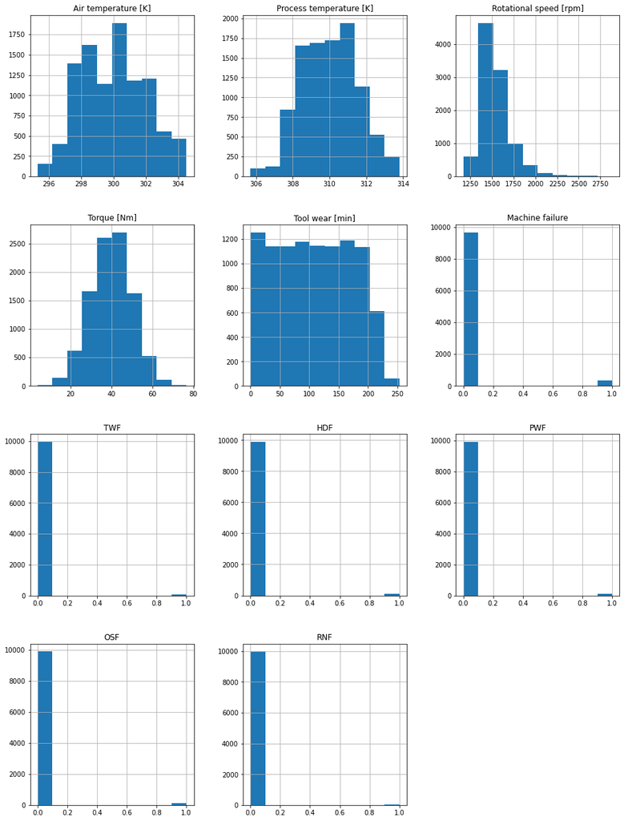

```python
df.hist(figsize=(16,22),bins=10)
plt.show()
```

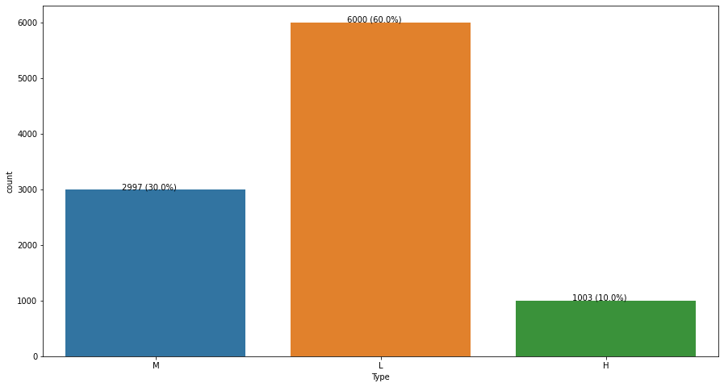

```python
plt.figure(figsize=(15,8))
ax = sns.countplot(data=df,x='Type')
for p in ax.patches:
    ax.annotate('{:.0f} ({:.1f}%)'.format(p.get_height(),(100 * p.get_height()/len(df.Type))), (p.get_x()+0.25, p.get_height()+0.04))
plt.show()
```

Here are M, L, and H are product quality variants where:

- L for low (60% of all products)
- M for medium (30%)
- H for high (10%)

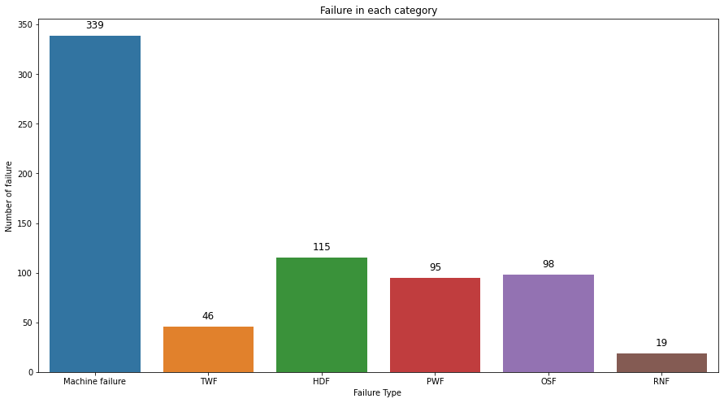

```python
labels = df.iloc[:,7:].sum().values
plt.figure(figsize=(15,8))
ax = sns.barplot(x=df.columns[7:],y=labels)
plt.title("Failure in each category")
plt.ylabel('Number of failure')
plt.xlabel('Failure Type ')
#adding the text labels
rects = ax.patches
for rect, label in zip(rects, labels):
    height = rect.get_height()
    ax.text(rect.get_x() + rect.get_width()/2, height + 5, label, ha='center', va='bottom', fontsize=12)
plt.show()
```

There are Most of the **machine failure** happened because of the **Heat dissipation failure(HDF)** which is 115, and very less cases of **Random failures** which is 19.

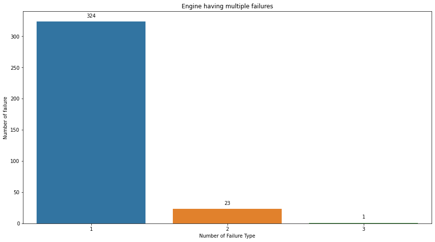

```python
rowSums = df.iloc[:,8:].sum(axis=1)
multiLabel_counts = rowSums.value_counts()
multiLabel_counts = multiLabel_counts.iloc[1:]

plt.figure(figsize=(15,8))
ax = sns.barplot(x = multiLabel_counts.index, y = multiLabel_counts.values)
plt.title("Engine having multiple failures")
plt.ylabel('Number of failure')
plt.xlabel('Number of Failure Type')
#adding the text labels
rects = ax.patches
labels = multiLabel_counts.values
for rect, label in zip(rects, labels):
    height = rect.get_height()
    ax.text(rect.get_x() + rect.get_width()/2, height + 5, label, ha='center', va='bottom')
plt.show()
```

The engine can have more than one type of failure at once, which we can observe from above graph where 23 engines are having 2 type for failure and 1 engine is having 3 type of failure at once.

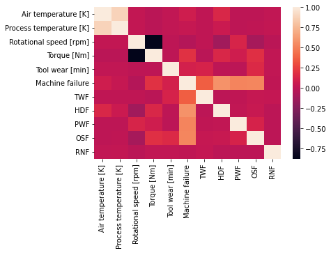

```python
### plt.figure(figsize=(7,7))
sns.heatmap(df.corr())
plt.show()
```

Here we can notice **TWF, HDF, PWF, and OSF** are correleted with **Machine failure** attribute, it is because if at least one of these modes is true, the process fails and the **Machine failure** label is set to 1.

Also **RNF** attribute is showing 0 correlation with **Machine failure**

```python
# Checking is there any row where Machine failure is 0 but any other failure mode is set to 1
df[(df['Machine failure']==0) & (df[['TWF', 'HDF', 'PWF', 'OSF', 'RNF']] == 1).any(axis=1)]
```

|  | Product ID | Type | Air temperature [K] | Process temperature [K] | Rotational speed [rpm] | Torque [Nm] | Tool wear [min] | Machine failure | TWF | HDF | PWF | OSF | RNF |
| --- | --- | --- | --- | --- | --- | --- | --- | --- | --- | --- | --- | --- | --- |
| 1221 | M16081 | M | 297.0 | 308.3 | 1399 | 46.4 | 132 | 0 | 0 | 0 | 0 | 0 | 1 |
| 1302 | L48482 | L | 298.6 | 309.8 | 1505 | 45.7 | 144 | 0 | 0 | 0 | 0 | 0 | 1 |
| 1748 | H31162 | H | 298.4 | 307.7 | 1626 | 31.1 | 166 | 0 | 0 | 0 | 0 | 0 | 1 |
| 2072 | L49252 | L | 299.6 | 309.5 | 1570 | 35.5 | 189 | 0 | 0 | 0 | 0 | 0 | 1 |
| 2559 | L49739 | L | 299.3 | 309.0 | 1447 | 50.4 | 140 | 0 | 0 | 0 | 0 | 0 | 1 |
| 3065 | M17925 | M | 300.1 | 309.2 | 1687 | 27.7 | 95 | 0 | 0 | 0 | 0 | 0 | 1 |
| 3452 | H32866 | H | 301.6 | 310.5 | 1602 | 32.3 | 2 | 0 | 0 | 0 | 0 | 0 | 1 |
| 5471 | L52651 | L | 302.7 | 312.3 | 1346 | 61.2 | 170 | 0 | 0 | 0 | 0 | 0 | 1 |
| 5489 | L52669 | L | 302.6 | 312.1 | 1499 | 35.0 | 215 | 0 | 0 | 0 | 0 | 0 | 1 |
| 5495 | H34909 | H | 302.9 | 312.5 | 1357 | 55.0 | 12 | 0 | 0 | 0 | 0 | 0 | 1 |
| 5509 | L52689 | L | 302.8 | 312.2 | 1509 | 36.5 | 52 | 0 | 0 | 0 | 0 | 0 | 1 |
| 5553 | L52733 | L | 302.5 | 311.9 | 1306 | 59.7 | 172 | 0 | 0 | 0 | 0 | 0 | 1 |
| 5639 | L52819 | L | 302.6 | 312.1 | 1668 | 28.7 | 180 | 0 | 0 | 0 | 0 | 0 | 1 |
| 6091 | L53271 | L | 300.9 | 310.7 | 1412 | 57.5 | 16 | 0 | 0 | 0 | 0 | 0 | 1 |
| 6913 | L54093 | L | 300.8 | 311.2 | 1481 | 38.5 | 181 | 0 | 0 | 0 | 0 | 0 | 1 |
| 6960 | L54140 | L | 300.7 | 311.0 | 1413 | 52.0 | 91 | 0 | 0 | 0 | 0 | 0 | 1 |
| 7488 | L54668 | L | 300.3 | 311.7 | 1545 | 43.5 | 160 | 0 | 0 | 0 | 0 | 0 | 1 |
| 7868 | H37282 | H | 300.4 | 311.9 | 1438 | 46.7 | 41 | 0 | 0 | 0 | 0 | 0 | 1 |

There are 18 rows where **Machine failure** is 0 but **RNF** is set to 1, to solve this issue we'll need to do some feature engineering.

## Feature Engineering

As we know there are 2 columns which are object type where we'll drop **Product ID** column but **Type** attribute is useful feature which we can use by converting it into numerical data type, where we'll use one hot encoding for this.

We also need to remove other columns which explains type of failure like **TWF, HDF, PWF, OSF, and RNF** because we won't have this data before prediction so including this feature into machine learning model can cause data leakage which will perform better in test data but will give bad performance on real data prediction.

```python
# ohdf = pd.get_dummies(df,columns=['Type']).drop(['Product ID', 'Machine failure'],axis=1)
ohdf = pd.get_dummies(df,columns=['Type']).drop(['Product ID', 'TWF', 'HDF', 'PWF', 'OSF', 'RNF'],axis=1)
ohdf.head()
```

|  | Air temperature [K] | Process temperature [K] | Rotational speed [rpm] | Torque [Nm] | Tool wear [min] | Machine failure | Type_H | Type_L | Type_M |
| --- | --- | --- | --- | --- | --- | --- | --- | --- | --- |
| 0 | 298.1 | 308.6 | 1551 | 42.8 | 0 | 0 | 0 | 0 | 1 |
| 1 | 298.2 | 308.7 | 1408 | 46.3 | 3 | 0 | 0 | 1 | 0 |
| 2 | 298.1 | 308.5 | 1498 | 49.4 | 5 | 0 | 0 | 1 | 0 |
| 3 | 298.2 | 308.6 | 1433 | 39.5 | 7 | 0 | 0 | 1 | 0 |
| 4 | 298.2 | 308.7 | 1408 | 40.0 | 9 | 0 | 0 | 1 | 0 |

We also need to set **Machine Failure** attribute to 1 where **RNF** is set 1

```python
ind = df[df['RNF'] == 1].index
ohdf.loc[ind,'Machine failure'] = 1
```

```python
ohdf.loc[ind,]
```

|  | Air temperature [K] | Process temperature [K] | Rotational speed [rpm] | Torque [Nm] | Tool wear [min] | Machine failure | Type_H | Type_L | Type_M |
| --- | --- | --- | --- | --- | --- | --- | --- | --- | --- |
| 1221 | 297.0 | 308.3 | 1399 | 46.4 | 132 | 1 | 0 | 0 | 1 |
| 1302 | 298.6 | 309.8 | 1505 | 45.7 | 144 | 1 | 0 | 1 | 0 |
| 1748 | 298.4 | 307.7 | 1626 | 31.1 | 166 | 1 | 1 | 0 | 0 |
| 2072 | 299.6 | 309.5 | 1570 | 35.5 | 189 | 1 | 0 | 1 | 0 |
| 2559 | 299.3 | 309.0 | 1447 | 50.4 | 140 | 1 | 0 | 1 | 0 |
| 3065 | 300.1 | 309.2 | 1687 | 27.7 | 95 | 1 | 0 | 0 | 1 |
| 3452 | 301.6 | 310.5 | 1602 | 32.3 | 2 | 1 | 1 | 0 | 0 |
| 3611 | 301.7 | 310.9 | 1405 | 46.4 | 207 | 1 | 0 | 1 | 0 |
| 5471 | 302.7 | 312.3 | 1346 | 61.2 | 170 | 1 | 0 | 1 | 0 |
| 5489 | 302.6 | 312.1 | 1499 | 35.0 | 215 | 1 | 0 | 1 | 0 |
| 5495 | 302.9 | 312.5 | 1357 | 55.0 | 12 | 1 | 1 | 0 | 0 |
| 5509 | 302.8 | 312.2 | 1509 | 36.5 | 52 | 1 | 0 | 1 | 0 |
| 5553 | 302.5 | 311.9 | 1306 | 59.7 | 172 | 1 | 0 | 1 | 0 |
| 5639 | 302.6 | 312.1 | 1668 | 28.7 | 180 | 1 | 0 | 1 | 0 |
| 6091 | 300.9 | 310.7 | 1412 | 57.5 | 16 | 1 | 0 | 1 | 0 |
| 6913 | 300.8 | 311.2 | 1481 | 38.5 | 181 | 1 | 0 | 1 | 0 |
| 6960 | 300.7 | 311.0 | 1413 | 52.0 | 91 | 1 | 0 | 1 | 0 |
| 7488 | 300.3 | 311.7 | 1545 | 43.5 | 160 | 1 | 0 | 1 | 0 |
| 7868 | 300.4 | 311.9 | 1438 | 46.7 | 41 | 1 | 1 | 0 | 0 |

```python
ohdf['Temp differece'] = ohdf['Process temperature [K]'] - ohdf['Air temperature [K]']
```

```python
ohdf['Power'] = ohdf['Torque [Nm]'] * ((ohdf['Rotational speed [rpm]'] * np.pi) / 30)
```

```python
ohdf['Strain'] = ohdf['Torque [Nm]'] * ohdf['Tool wear [min]']
```

```python
ohdf.head()
```

|  | Air temperature [K] | Process temperature [K] | Rotational speed [rpm] | Torque [Nm] | Tool wear [min] | Machine failure | Type_H | Type_L | Type_M | Temp differece | Power | Strain |
| --- | --- | --- | --- | --- | --- | --- | --- | --- | --- | --- | --- | --- |
| 0 | 298.1 | 308.6 | 1551 | 42.8 | 0 | 0 | 0 | 0 | 1 | 10.5 | 6951.590560 | 0.0 |
| 1 | 298.2 | 308.7 | 1408 | 46.3 | 3 | 0 | 0 | 1 | 0 | 10.5 | 6826.722724 | 138.9 |
| 2 | 298.1 | 308.5 | 1498 | 49.4 | 5 | 0 | 0 | 1 | 0 | 10.4 | 7749.387543 | 247.0 |
| 3 | 298.2 | 308.6 | 1433 | 39.5 | 7 | 0 | 0 | 1 | 0 | 10.4 | 5927.504659 | 276.5 |
| 4 | 298.2 | 308.7 | 1408 | 40.0 | 9 | 0 | 0 | 1 | 0 | 10.5 | 5897.816608 | 360.0 |

```python
X = ohdf.copy()
y = X.pop('Machine failure')
```

```python
# print("Before",Counter(y))
# smote = SMOTE(random_state = 101)
# X, y = smote.fit_resample(X,y)
# print("After",Counter(y))
```

```python
X_train, X_test, y_train, y_test = train_test_split(X, y, test_size = 0.20, random_state = 21, stratify=y)
```

```python
# X_test.to_csv('X_test.csv',index=False)
# y_test.to_csv('y_test.csv',index=False)
```

```python
from sklearn.preprocessing import MinMaxScaler, StandardScaler
# scaler = StandardScaler()
scaler = MinMaxScaler()
scaled_values = scaler.fit_transform(X_train)
X_train.loc[:,:] = scaled_values
scaled_values = scaler.transform(X_test)
X_test.loc[:,:] = scaled_values
# saving the minmaxscaler weights
joblib.dump(scaler, 'MinMaxScaler.bin', compress=True)
X_train.head()
```

|  | Air temperature [K] | Process temperature [K] | Rotational speed [rpm] | Torque [Nm] | Tool wear [min] | Type_H | Type_L | Type_M | Temp differece | Power | Strain |
| --- | --- | --- | --- | --- | --- | --- | --- | --- | --- | --- | --- |
| 9959 | 0.304348 | 0.259259 | 0.122817 | 0.622253 | 0.533597 | 0.0 | 1.0 | 0.0 | 0.466667 | 0.662903 | 0.401800 |
| 8411 | 0.358696 | 0.506173 | 0.190920 | 0.465659 | 0.529644 | 0.0 | 1.0 | 0.0 | 0.800000 | 0.530775 | 0.306225 |
| 6272 | 0.630435 | 0.604938 | 0.151921 | 0.671703 | 0.138340 | 0.0 | 0.0 | 1.0 | 0.422222 | 0.751685 | 0.111808 |
| 3859 | 0.793478 | 0.716049 | 0.250873 | 0.456044 | 0.833992 | 0.0 | 1.0 | 0.0 | 0.288889 | 0.563063 | 0.473238 |
| 5021 | 0.945652 | 0.901235 | 0.105937 | 0.787088 | 0.347826 | 0.0 | 1.0 | 0.0 | 0.311111 | 0.835528 | 0.325926 |

#### Oversampling the dataset

As we know, the dataset is imbalanced and if we train the model with this dataset then it will give better performance on the testing dataset but it will not give good performance on real time dataset. To overcome with this issue we'll perform oversampling.

```python
print("Before",Counter(y_train))
smt = SMOTE(random_state = 101)
X_train, y_train = smt.fit_resample(X_train,y_train)
print("After",Counter(y_train))
```

```
Before Counter({0: 7714, 1: 286})
```

[output not shown]

## Machine Learning

Now to predict the engine failure, we will apply different machine learning algorithms, and check which machine learning algorithm is giving better performance, for model evaluation we'll use multiple parameters like: - F1 score, Confusion Matrix, Auc etc.

### 1. Random Forest Classification

```
F1 Score:  0.7142857142857142
              precision    recall  f1-score   support

           0       0.99      0.98      0.99      1929
           1       0.62      0.85      0.71        71

    accuracy                           0.98      2000
   macro avg       0.81      0.91      0.85      2000
weighted avg       0.98      0.98      0.98      2000

Area under curve :  0.9129447498886528
```

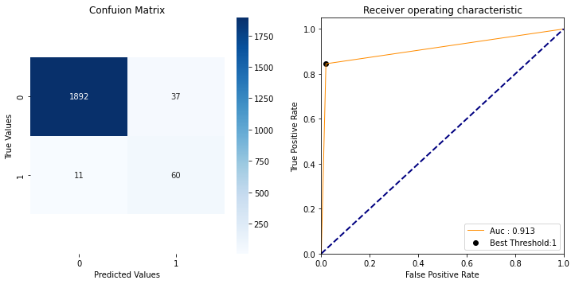

```python
model_data = {}
RFclassifier = RandomForestClassifier(n_estimators = 35, random_state = 42)
RFclassifier.fit(X_train, y_train)
y_pred = RFclassifier.predict(X_test)
model_data['Random Forest'] = print_results(y_test,y_pred)
```

```python
# Training Data Evalaution
y_pred_train = RFclassifier.predict(X_train)



cnf_matrix = confusion_matrix(y_train, y_pred_train)
print("Confusion Matrix :\n",cnf_matrix)



acc_score = accuracy_score(y_train, y_pred_train)
print("Accuracy Score :",acc_score)



clf_report = classification_report(y_train, y_pred_train)
print("Classification Report :\n",clf_report)
```

```
Confusion Matrix :
 [[7714    0]
 [   0 7714]]
Accuracy Score : 1.0
Classification Report :
               precision    recall  f1-score   support

           0       1.00      1.00      1.00      7714
           1       1.00      1.00      1.00      7714

    accuracy                           1.00     15428
   macro avg       1.00      1.00      1.00     15428
weighted avg       1.00      1.00      1.00     15428
```

```python
# Training Data Evalaution
y_pred_test = RFclassifier.predict(X_test)



cnf_matrix = confusion_matrix(y_test, y_pred_test)
print("Confusion Matrix :\n",cnf_matrix)



acc_score = accuracy_score(y_test, y_pred_test)
print("Accuracy Score :",acc_score)



clf_report = classification_report(y_test, y_pred_test)
print("Classification Report :\n",clf_report)
```

```
Confusion Matrix :
 [[1892   37]
 [  11   60]]
Accuracy Score : 0.976
Classification Report :
               precision    recall  f1-score   support

           0       0.99      0.98      0.99      1929
           1       0.62      0.85      0.71        71

    accuracy                           0.98      2000
   macro avg       0.81      0.91      0.85      2000
weighted avg       0.98      0.98      0.98      2000
```

### Hyperperameter tuning

```python
random = RandomForestClassifier()

hyp = {'n_estimators':np.arange(70,300,10),
       'criterion':['gini','entropy'],
       'max_depth':np.arange(1,15),
       'min_samples_split':np.arange(2,20),
       'min_samples_leaf':np.arange(2,20),
       'max_features':['sqrt','log2']
      }

RF_rscv = RandomizedSearchCV(random,hyp,cv=10)
RF_rscv.fit(X_train,y_train)
```

```
RandomizedSearchCV(cv=10, estimator=RandomForestClassifier(),
                   param_distributions={'criterion': ['gini', 'entropy'],
                                        'max_depth': array([ 1,  2,  3,  4,  5,  6,  7,  8,  9, 10, 11, 12, 13, 14]),
                                        'max_features': ['sqrt', 'log2'],
                                        'min_samples_leaf': array([ 2,  3,  4,  5,  6,  7,  8,  9, 10, 11, 12, 13, 14, 15, 16, 17, 18,
       19]),
                                        'min_samples_split': array([ 2,  3,  4,  5,  6,  7,  8,  9, 10, 11, 12, 13, 14, 15, 16, 17, 18,
       19]),
                                        'n_estimators': array([ 70,  80,  90, 100, 110, 120, 130, 140, 150, 160, 170, 180, 190,
       200, 210, 220, 230, 240, 250, 260, 270, 280, 290])})
```

```python
RF_rscv.best_estimator_
```

```
RandomForestClassifier(max_depth=12, max_features='log2', min_samples_leaf=16,
                       min_samples_split=19, n_estimators=70)
```

```python
RF_rscv.best_params_
```

```
{'n_estimators': 70,
 'min_samples_split': 19,
 'min_samples_leaf': 16,
 'max_features': 'log2',
 'max_depth': 12,
 'criterion': 'gini'}
```

```python
RFclassifier=RandomForestClassifier(max_depth=12, max_features='log2', min_samples_leaf=16,
                       min_samples_split=19, n_estimators=70)
RFclassifier.fit(X_train,y_train)
```

```
RandomForestClassifier(max_depth=12, max_features='log2', min_samples_leaf=16,
                       min_samples_split=19, n_estimators=70)
```

```python
# Training Data Evalaution
y_pred_train = RFclassifier.predict(X_train)



cnf_matrix = confusion_matrix(y_train, y_pred_train)
print("Confusion Matrix :\n",cnf_matrix)



acc_score = accuracy_score(y_train, y_pred_train)
print("Accuracy Score :",acc_score)



clf_report = classification_report(y_train, y_pred_train)
print("Classification Report :\n",clf_report)
```

```
Confusion Matrix :
 [[7447  267]
 [ 348 7366]]
Accuracy Score : 0.9601374124967591
Classification Report :
               precision    recall  f1-score   support

           0       0.96      0.97      0.96      7714
           1       0.97      0.95      0.96      7714

    accuracy                           0.96     15428
   macro avg       0.96      0.96      0.96     15428
weighted avg       0.96      0.96      0.96     15428
```

```python
# Testing Data Evalaution
y_pred_test = RFclassifier.predict(X_test)



cnf_matrix = confusion_matrix(y_test, y_pred_test)
print("Confusion Matrix :\n",cnf_matrix)



acc_score = accuracy_score(y_test, y_pred_test)
print("Accuracy Score :",acc_score)



clf_report = classification_report(y_test, y_pred_test)
print("Classification Report :\n",clf_report)
```

```
Confusion Matrix :
 [[1851   78]
 [   9   62]]
Accuracy Score : 0.9565
Classification Report :
               precision    recall  f1-score   support

           0       1.00      0.96      0.98      1929
           1       0.44      0.87      0.59        71

    accuracy                           0.96      2000
   macro avg       0.72      0.92      0.78      2000
weighted avg       0.98      0.96      0.96      2000
```

### 2. Naive Bayes Classification

```
F1 Score:  0.8547091749817474
              precision    recall  f1-score   support

           0       0.90      0.78      0.83      1929
           1       0.81      0.91      0.85      1929

    accuracy                           0.85      3858
   macro avg       0.85      0.85      0.84      3858
weighted avg       0.85      0.85      0.84      3858

Area under curve :  0.8452566096423018
```

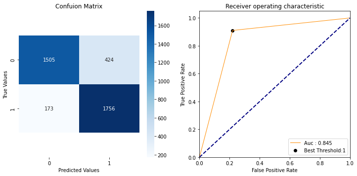

```python
from sklearn.naive_bayes import GaussianNB
gnb = GaussianNB()
gnb.fit(X_train, y_train)
y_pred = gnb.predict(X_test)
model_data['Naive Bayes'] = print_results(y_test,y_pred)
```

### 3. Logistic Regression Classification

```
F1 Score:  0.8802779262426511
              precision    recall  f1-score   support

           0       0.86      0.91      0.89      1929
           1       0.91      0.85      0.88      1929

    accuracy                           0.88      3858
   macro avg       0.89      0.88      0.88      3858
weighted avg       0.89      0.88      0.88      3858

Area under curve :  0.8838776568170037
```

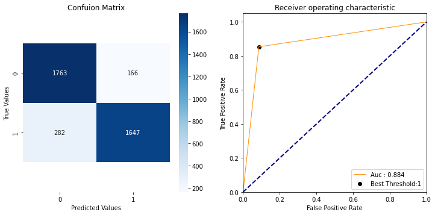

```python
from sklearn.linear_model import LogisticRegression
LRG = LogisticRegression(random_state = 0,solver = 'liblinear')
LRG.fit(X_train, y_train)
y_pred = LRG.predict(X_test)
model_data['Logistic Regression'] = print_results(y_test,y_pred)
```

### 4. Support Vector Machine Classification

```
F1 Score:  0.9283637324874439
              precision    recall  f1-score   support

           0       0.91      0.95      0.93      1929
           1       0.95      0.91      0.93      1929

    accuracy                           0.93      3858
   macro avg       0.93      0.93      0.93      3858
weighted avg       0.93      0.93      0.93      3858

Area under curve :  0.9297563504406429
```

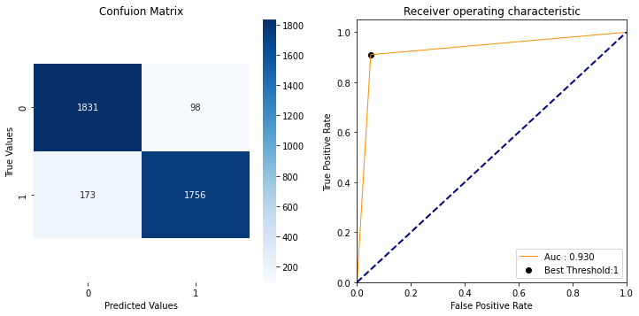

```python
from sklearn.svm import SVC
svc = SVC()
svc.fit(X_train, y_train)
y_pred = svc.predict(X_test)
model_data['Support Vector Machine'] = print_results(y_test,y_pred)
```

### 5. K Nearest Neighbor Classification

```
F1 Score:  0.9609335362760021
              precision    recall  f1-score   support

           0       0.98      0.94      0.96      1929
           1       0.94      0.98      0.96      1929

    accuracy                           0.96      3858
   macro avg       0.96      0.96      0.96      3858
weighted avg       0.96      0.96      0.96      3858

Area under curve :  0.960082944530845
```

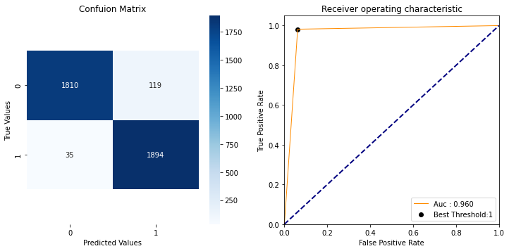

```python
from sklearn.neighbors import KNeighborsClassifier
knn = KNeighborsClassifier()
knn.fit(X_train, y_train)
y_pred = knn.predict(X_test)
model_data['K Nearest Neighbor'] = print_results(y_test,y_pred)
```

## Conclusion

Let's compare all the machine learning algorithms with their **F1 Score**. The better the algorithm will be the more the F1 score will be.

```python
# pd.Series(model_data).to_frame('F1 Score')
print(*list(map(lambda x:str(x).ljust(25),('ML Model','F1 Score'))),sep='|  ')
print(('-'*25)+'+'+('-'*21))
for k,v in model_data.items():
    print(*list(map(lambda x:str(x).ljust(25),(k,v))),sep='|  ')
```

```
ML Model                 |  F1 Score
-------------------------+---------------------
Random Forest            |  0.9901401141670991
Naive Bayes              |  0.8547091749817474
Logistic Regression      |  0.8802779262426511
Support Vector Machine   |  0.9283637324874439
K Nearest Neighbor       |  0.9609335362760021
```

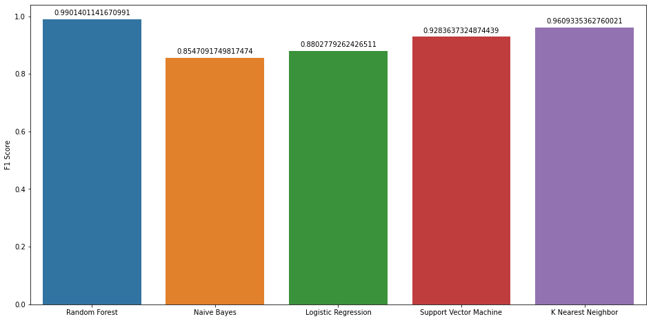

```python
# sns.barplot(x=model_data.keys(),y=model_data.values())
keys = list(model_data.keys())
values = list(model_data.values())
plt.figure(figsize=(16,8))
ax = sns.barplot(x=keys,y=values)
rects = ax.patches
for rect, label in zip(rects, values):
    height = rect.get_height()
    ax.text(rect.get_x() + rect.get_width()/2, height+.01, label, ha='center', va='bottom')
plt.ylabel("F1 Score")
plt.show()
```

```python
# save the model to disk
filename = 'engine_maintenance_model.sav'
joblib.dump(RFclassifier, filename)
```

```
['engine_maintenance_model.sav']
```

```
F1 Score:  0.9901401141670991
              precision    recall  f1-score   support

           0       0.99      0.99      0.99      1929
           1       0.99      0.99      0.99      1929

    accuracy                           0.99      3858
   macro avg       0.99      0.99      0.99      3858
weighted avg       0.99      0.99      0.99      3858

Area under curve :  0.9901503369621566
```

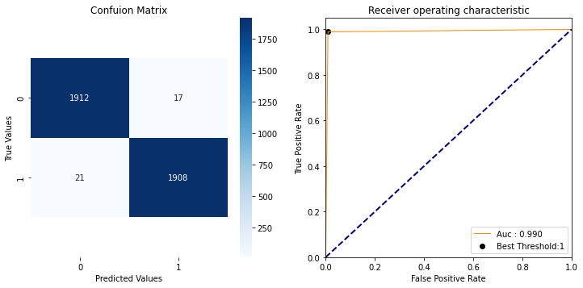

```python
# load the model from disk
loaded_model = joblib.load(filename)
y_pred = loaded_model.predict(X_test)
model_data['Random Forest'] = print_results(y_test,y_pred)
```

```python
X_test.to_csv('X_test.csv',index=False)
y_test.to_csv('y_test.csv',index=False)
```